# Exploiting matrix structure

## Example 2.9.1 (Banded matrices)

Here is a matrix with both lower and upper bandwidth equal to one. Such a matrix is called tridiagonal.

```python
from numpy import array
A = array([
    [2, -1,  0,  0,  0,  0],
    [4,  2, -1,  0,  0,  0],
    [0,  3,  0, -1,  0,  0],
    [0,  0,  2,  2, -1,  0],
    [0,  0,  0,  1,  1, -1],
    [0,  0,  0,  0,  0,  2 ]
    ])
```

We can extract the elements on any diagonal using the $\texttt{diag}$ command. The ``main'' or central diagonal is numbered zero, above and to the right of that is positive, and below and to the left is negative.

```python
from  numpy import diag
print( diag(A) )
```

```
[2 2 0 2 1 2]
```

```python
print( diag(A, 1) )
```

```
[-1 -1 -1 -1 -1]
```

```python
print( diag(A, -1) )
```

```
[4 3 2 1 0]
```

We can also construct matrices by specifying a diagonal with the diag function.

```python
from numpy import diag
from numpy import pi
A = A + diag([pi, 8, 6, 7], 2)
print(A)
```

```
[[ 2.         -1.          3.14159265  0.          0.          0.        ]
 [ 4.          2.         -1.          8.          0.          0.        ]
 [ 0.          3.          0.         -1.          6.          0.        ]
 [ 0.          0.          2.          2.         -1.          7.        ]
 [ 0.          0.          0.          1.          1.         -1.        ]
 [ 0.          0.          0.          0.          0.          2.        ]]
```

```python
def plufact(A):
    """
        plufact(A)

    Compute the PLU factorization of square matrix A, returning the
    triangular factors and a row permutation vector.
    """
    n = A.shape[0]
    L = np.zeros((n, n))
    U = np.zeros((n, n))
    p = np.zeros(n, dtype=int)
    A_k = np.copy(A.astype(float))

    # Reduction by outer products
    for k in range(n):
        p[k] = np.argmax(abs(A_k[:, k]))
        U[k, :] = A_k[p[k], :]
        L[:, k] = A_k[:, k] / U[k, k]
        if k < n-1:
            A_k -= np.outer(L[:, k], U[k, :])
    return L[p, :], U, p
```

```python
def lufact(A):
    """
    lufact(A)

    Compute the LU factorization of square matrix A, returning the
    factors.
    """
    n = A.shape[0]     # detect the dimensions from the input
    L = np.eye(n)      # ones on main diagonal, zeros elsewhere
    U = np.zeros((n, n))
    A_k = np.copy(A.astype(float))    # make a working copy

    # Reduction by np.outer products
    for k in range(n-1):
        U[k, :] = A_k[k, :]
        L[:, k] = A_k[:, k] / U[k,k]
        A_k -= np.outer(L[:,k], U[k,:])
    U[n-1, n-1] = A_k[n-1, n-1]
    return L, U
```

```python
L, U = lufact(A)
print(L)
```

```
[[1.         0.         0.         0.         0.         0.        ]
 [2.         1.         0.         0.         0.         0.        ]
 [0.         0.75       1.         0.         0.         0.        ]
 [0.         0.         0.36614016 1.         0.         0.        ]
 [0.         0.         0.         0.21915497 1.         0.        ]
 [0.         0.         0.         0.         0.         1.        ]]
```

```python
print(U)
```

```
[[ 2.         -1.          3.14159265  0.          0.          0.        ]
 [ 0.          4.         -7.28318531  8.          0.          0.        ]
 [ 0.          0.          5.46238898 -7.          6.          0.        ]
 [ 0.          0.          0.          4.56298115 -3.19684099  7.        ]
 [ 0.          0.          0.          0.          1.70060359 -2.53408479]
 [ 0.          0.          0.          0.          0.          2.        ]]
```

Observe above that the lower and upper bandwidths of $A$ are preserved in the factor matrices.

## Example 2.9.2(Symmetric $LDL^T$factorization)

We begin with a symmetric $A$

```python
A_1 = array([
    [2,     4,     4,     2],
    [4,     5,     8,    -5],
    [4,     8,     6,     2],
    [2,    -5,     2,   -26]
    ])
```

We won’t use pivoting, so the pivot element is at position $(1,1)$. This will become the first element on the diagonal of $\mathbf{D}$. Then we divide by that pivot to get the first column of $\mathbf{L}$.

```python
from numpy import eye ,zeros ,outer
L = eye(4)
d = zeros(4)
d[0] = A_1[0, 0]
L[:, 0] = A_1[:, 0] / d[0]
A_2 = A_1 - d[0] * outer(L[:, 0], L[:, 0])
print(A_2)
```

```
[[  0.   0.   0.   0.]
 [  0.  -3.   0.  -9.]
 [  0.   0.  -2.  -2.]
 [  0.  -9.  -2. -28.]]
```

We are now set up the same way for the submatrix in rows and columns 2–4.

```python
d[1] = A_2[1, 1]
L[:, 1] = A_2[:, 1] / d[1]
A_3 = A_2 - d[1] * outer(L[:, 1], L[:, 1])
print(A_3)
```

```
[[ 0.  0.  0.  0.]
 [ 0.  0.  0.  0.]
 [ 0.  0. -2. -2.]
 [ 0.  0. -2. -1.]]
```

We continue working our way down the diagonal.

```python
d[2] = A_3[2, 2]
L[:, 2] = A_3[:, 2] / d[2]
A_4 = A_3 - d[2] * outer(L[:, 2], L[:, 2])
print(A_4)
```

```
[[0. 0. 0. 0.]
 [0. 0. 0. 0.]
 [0. 0. 0. 0.]
 [0. 0. 0. 1.]]
```

We have arrived at the desired factorization.

```python
d[3] = A_4[3, 3]
print("diagonal of D:")
print(d)
print("L:")
print(L)
```

```
diagonal of D:
[ 2. -3. -2.  1.]
L:
[[ 1. -0. -0.  0.]
 [ 2.  1. -0.  0.]
 [ 2. -0.  1.  0.]
 [ 1.  3.  1.  1.]]
```

This should be comparable to machine roundoff:

```python
from numpy.linalg import norm
print(norm(A_1 - (L @ diag(d) @ L.T), 2) / norm(A_1))
```

```
0.0
```

## Example 2.9.3(Cholesky factorization)

A randomly chosen matrix is extremely unlikely to be symmetric. However, there is a simple way to symmetrize one.

```python
from numpy import floor ,random
A = 1.0 + floor(9 * random.rand(4, 4))
B = A + A.T
print(B)
```

```
[[12. 10. 11. 10.]
 [10.  2. 11. 14.]
 [11. 11.  2. 12.]
 [10. 14. 12. 10.]]
```

Similarly, a random symmetric matrix is unlikely to be positive definite. The Cholesky algorithm always detects a non-PD matrix by quitting with an error.

```python
from numpy.linalg import cholesky
cholesky(B)    # raises an exception, not positive definite
```

```
---------------------------------------------------------------------------
LinAlgError                               Traceback (most recent call last)
/tmp/ipython-input-1938187923.py in <cell line: 0>()
      1 from numpy.linalg import cholesky
----> 2 cholesky(B)    # raises an exception, not positive definite

/usr/local/lib/python3.12/dist-packages/numpy/linalg/_linalg.py in cholesky(a, upper)
    837     with errstate(call=_raise_linalgerror_nonposdef, invalid='call',
    838                   over='ignore', divide='ignore', under='ignore'):
--> 839         r = gufunc(a, signature=signature)
    840     return wrap(r.astype(result_t, copy=False))
    841

/usr/local/lib/python3.12/dist-packages/numpy/linalg/_linalg.py in _raise_linalgerror_nonposdef(err, flag)
    105
    106 def _raise_linalgerror_nonposdef(err, flag):
--> 107     raise LinAlgError("Matrix is not positive definite")
    108
    109 def _raise_linalgerror_eigenvalues_nonconvergence(err, flag):

LinAlgError: Matrix is not positive definite
```

It’s not hard to manufacture an SPD matrix to try out the Cholesky factorization:

```python
B = A.T @ A
R = cholesky(B)
print(R)
```

```
[[11.70469991  0.          0.          0.        ]
 [ 6.40768243  4.35219552  0.          0.        ]
 [ 9.56880577 -2.14003911  2.42036956  0.        ]
 [12.7299291   1.01802801 -3.97939198  2.6602563 ]]
```

```python
print(norm(R @ R.T - B) / norm(B))
```

```
0.0
```

# Fitting functions to data

## Example 3.1.1 (Interpolating temperature data)

Here are 5-year averages of the worldwide temperature anomaly as compared to the 1951–1980 average (source: NASA).

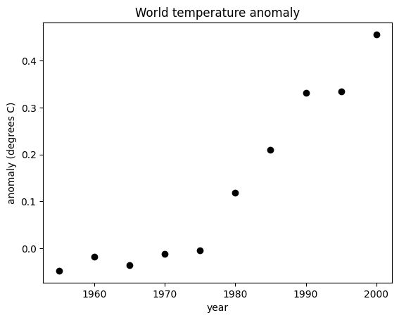

```python
from numpy import arange, array
from matplotlib.pyplot import subplots, xlabel, ylabel, title
year = arange(1955,2005,5)
y = array([ -0.0480, -0.0180, -0.0360, -0.0120, -0.0040,
    0.1180, 0.2100, 0.3320, 0.3340, 0.4560 ])

fig, ax = subplots()
ax.scatter(year, y, color="k", label="data")
xlabel("year")
ylabel("anomaly (degrees C)")
title("World temperature anomaly");
```

A polynomial interpolant can be used to fit the data. Here we build one using a Vandermonde matrix. First, though, we express time as decades since 1950, as it improves the condition number of the matrix.

```python
from numpy import vander
from scipy import linalg
t = (year - 1950) / 10
V = vander(t)
c = linalg.solve(V, y)
print(c)
```

```
[ 1.03111111e-02 -2.54666667e-01  2.69480635e+00 -1.59628889e+01
  5.80155778e+01 -1.33273472e+02  1.91960567e+02 -1.65455972e+02
  7.63617381e+01 -1.41140000e+01]
```

The coefficients in vector $c$ are used to create a polynomial. Then we create a function that evaluates the polynomial after changing the time variable as we did for the Vandermonde matrix.

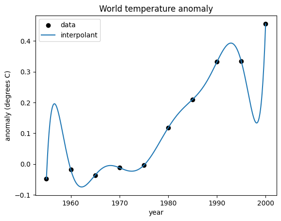

```python
from numpy import linspace, poly1d
from matplotlib.pyplot import plot
p = poly1d(c)    # convert to a polynomial
tt = linspace(1955, 2000, 500)
ax.plot(tt, p((tt - 1950) / 10), label="interpolant")
ax.legend();
fig
```

As you can see, the interpolant does represent the data, in a sense. However it’s a crazy-looking curve for the application. Trying too hard to reproduce all the data exactly is known as $overfitting$.

In many cases we can get better results by relaxing the interpolation requirement. In the polynomial case this allows us to lower the degree of the polynomial, which limits the number of local max and min points. Let $(t_i, y_i)$ for $i=1,\dots,m$ be the given points. We will represent the data by the polynomial \begin{equation} y \approx f(t) = c_1 + c_2 t + \cdots + c_{n-1} t^{n-2} + c_n t^{\,n-1}, \qquad (3.1.1) \end{equation} with $n < m$. Just as in (2.1.3), we can express a vector of $f$-values by a matrix-vector multiplication. In other words, we seek an approximation \begin{equation} \begin{bmatrix} y_1 \\ y_2 \\ y_3 \\ \vdots \\ y_m \end{bmatrix} \approx \begin{bmatrix} f(t_1) \\ f(t_2) \\ f(t_3) \\ \vdots \\ f(t_m) \end{bmatrix} = \begin{bmatrix} 1 & t_1 & \cdots & t_1^{\,n-1} \\ 1 & t_2 & \cdots & t_2^{\,n-1} \\ 1 & t_3 & \cdots & t_3^{\,n-1} \\ \vdots & \vdots & \ddots & \vdots \\ 1 & t_m & \cdots & t_m^{\,n-1} \end{bmatrix} \begin{bmatrix} c_1 \\ c_2 \\ \vdots \\ c_n \end{bmatrix} = Vc. \qquad (3.1.2) \end{equation}

Note that $V$ has the same structure as the Vandermonde matrix in (2.1.3) but is $m \times n$, thus taller than it is wide. It’s impossible in general to satisfy $m$ conditions with $n < m$ variables, and we say the system is $overdetermined$. Rather than solving the system exactly, we have to find the best approximation. Below we specify precisely what is meant by this, but first we note that Julia uses the same backslash notation to solve the problem in both the square and overdetermined cases.

## Example 3.1.2 (Fitting temperature data)

Here are the 5-year temperature averages again.

```python
year = arange(1955, 2005, 5)
y = array([-0.0480, -0.0180, -0.0360, -0.0120, -0.0040,
    0.1180, 0.2100, 0.3320, 0.3340, 0.4560])
t = (year - 1950) / 10
```

The standard best-fit line results from using a linear polynomial that meets the least-squares criterion.

```python
V = array([ [t[i], 1] for i in range(t.size) ])    # Vandermonde-ish matrix
print(V.shape)
print(V)
```

```
(10, 2)
[[0.5 1. ]
 [1.  1. ]
 [1.5 1. ]
 [2.  1. ]
 [2.5 1. ]
 [3.  1. ]
 [3.5 1. ]
 [4.  1. ]
 [4.5 1. ]
 [5.  1. ]]
```

```python
from scipy.linalg import lstsq
c, res, rank, sv = lstsq(V, y)
p = poly1d(c)
f = lambda year: p((year - 1950) / 10)
```

If we use a global cubic polynomial, the points are fit more closely.

```python
V = array([ [t[i]**3,t[i]**2,t[i],1] for i in range(t.size) ])    # Vandermonde-ish matrix
print(V.shape)
```

```
(10, 4)
```

Now we solve the new least-squares problem to redefine the fitting polynomial.

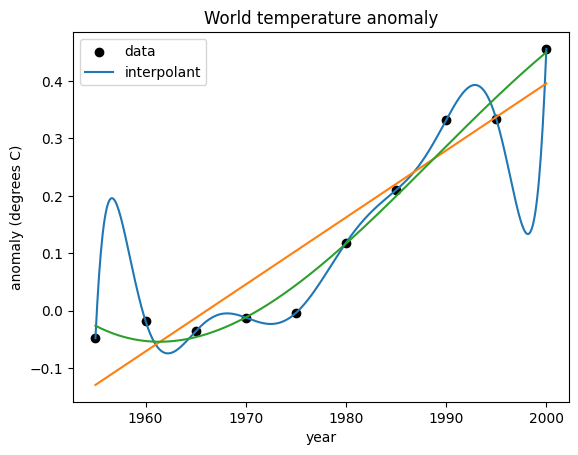

```python
c, res, rank, sv = lstsq(V, y)
p2 = poly1d(c)
f2 = lambda year: p2((year - 1950) / 10)
yr = linspace(1955, 2000, 500)
ax.plot(yr, f(yr), label="linear")
ax.plot(yr, f2(yr), label="cubic fit")
fig
```

If we were to continue increasing the degree of the polynomial, the residual at the data points would get smaller, but overfitting would increase.

## Example 3.1.3 (Fitting a power law)

Finding numerical approximations to $\pi$ has fascinated people for millennia. One famous formula is \begin{equation} \frac{\pi^2}{6} = 1 + \frac{1}{2^2} + \frac{1}{3^2} + \cdots . \tag{3.1.9} \end{equation}

Say $s_k$ is the sum of the first $k$ terms of the series above, and $p_k = \sqrt{6 s_k}$. Here is a fancy way to compute these sequences in a compact code.

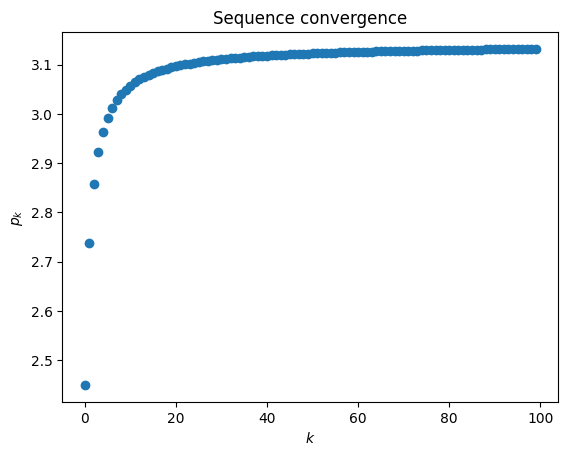

```python
from numpy import cumsum, sqrt
a = array([1 / (k+1)**2 for k in range(100)])
s = cumsum(a)        # cumulative summation
p = sqrt(6*s)

plot(range(100), p, "o")
xlabel("$k$")
ylabel("$p_k$")
title("Sequence convergence");
```

This graph suggests that maybe $p_k \to \pi$, but it’s far from clear how close the sequence gets. It’s more informative to plot the sequence of errors, \begin{equation} \epsilon_k = \lvert \pi - p_k \rvert . \end{equation} By plotting the error sequence on a log-log scale, we can see a nearly linear relationship.

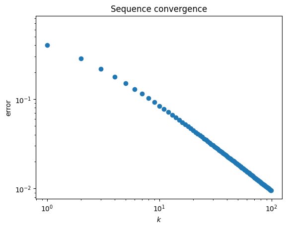

```python
from matplotlib.pyplot import loglog
ep = abs(pi - p)    # error sequence
loglog(range(100), ep, "o")
xlabel("$k$")
ylabel("error")
title("Sequence convergence");
```

The straight line on the log-log scale suggests a power-law relationship where \begin{equation} \epsilon_k \approx a k^b, \end{equation} or equivalently \begin{equation} \log \epsilon_k \approx b (\log k) + \log a . \end{equation}

```python
from numpy import log
V = array([ [1, log(k+1)] for k in range(100) ])     # fitting matrix
c = lstsq(V, log(ep))[0]           # coefficients of linear fit
print(c)
```

```
[-0.18237525 -0.96741032]
```

In terms of the parameters $a$ and $b$ used above, we have

```python
from numpy import exp
a, b = exp(c[0]), c[1]
print(f"b: {b:.3f}")
```

```
b: -0.967
```

It’s tempting to conjecture that the slope $b \to -1$ asymptotically. Here is how the numerical fit compares to the original convergence curve.

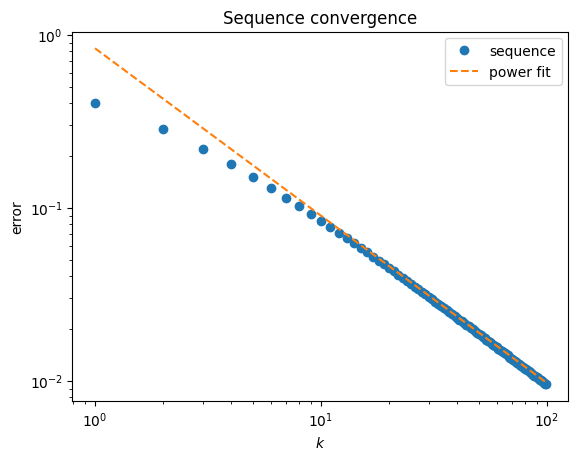

```python
from matplotlib.pyplot import legend
ep = abs(pi - p)    # error sequence
loglog(range(100), ep, "o", label="sequence")
k = arange(1,100)
plot(k, a*k**b, "--", label="power fit")
xlabel("$k$");  ylabel("error");
legend(); title("Sequence convergence");
```

# The normal equations

## Example 3.2.1(Instability in the normal equations)

Because the functions $\sin^{2}(t)$, $\cos^{2}(t)$, and $1$ are linearly dependent, we should find that the following matrix is somewhat ill-conditioned.

```python
from numpy.linalg import cond
from numpy import sin, cos
t = linspace(0, 3, 400)
A = array([ [sin(t)**2, cos((1+1e-7)*t)**2, 1] for t in t ])
kappa = cond(A)
print(f"cond(A) is {kappa:.3e}")
```

```
cond(A) is 1.825e+07
```

Now we set up an artificial linear least-squares problem with a known exact solution that actually makes the residual zero.

```python
x = array([1, 2, 1])
b = A @ x
```

Using backslash to find the least-squares solution, we get a relative error that is well below $κ$ times machine epsilon.

```python
from scipy.linalg import lstsq
from numpy.linalg import norm
from numpy import finfo
x_BS = lstsq(A, b)[0]
print(f"observed error: {norm(x_BS - x) / norm(x):.3e}")
print(f"conditioning bound: {kappa * finfo(float).eps:.3e}")
```

```
observed error: 6.642e-11
conditioning bound: 4.053e-09
```

If we formulate and solve via the normal equations, we get a much larger relative error. With $\kappa^2 \approx 10^{14}$, we may not be left with more than about 2 accurate digits.

```python
from scipy import linalg
from numpy import log10
N = A.T @ A
x_NE = linalg.solve(N, A.T @ b)
relative_err = norm(x_NE - x) / norm(x)
print(f"observed error: {relative_err:.3e}")
print(f"accurate digits: {-log10(relative_err):.2f}")
```

```
observed error: 3.626e-03
accurate digits: 2.44
```

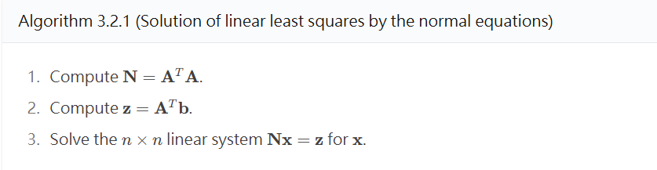

# The QR factorization

## Example 3.3.1 (QR factorization)

NumPy provides access to both the thin and full forms of the QR factorization.

```python
A = 1.0 + floor(9 * random.rand(6,4))
A.shape
```

```
(6, 4)
```

Here is the full form:

```python
from numpy.linalg import qr
Q, R = qr(A, "complete")
print(f"size of Q is {Q.shape}")
print("R:")
print(R)
```

```
size of Q is (6, 6)
R:
[[-13.56465997 -10.98442573 -10.32093693  -7.66698172]
 [  0.         -10.26364415  -5.90730094  -0.17368185]
 [  0.           0.          -3.68538416   2.21318196]
 [  0.           0.           0.          -2.8790713 ]
 [  0.           0.           0.           0.        ]
 [  0.           0.           0.           0.        ]]
```

We can test that $\mathit{Q}$ is an orthogonal matrix:

```python
print(f"norm of (Q^T Q - I) is {norm(Q.T @ Q - eye(6)):.3e}")
```

```
norm of (Q^T Q - I) is 1.088e-15
```

The default for $qr$, and the one you usually want, is the thin form.

```python
Q_hat, R_hat = qr(A)
print(f"size of Q_hat is {Q_hat.shape}")
print("R_hat:")
print(R_hat)
```

```
size of Q_hat is (6, 4)
R_hat:
[[-13.56465997 -10.98442573 -10.32093693  -7.66698172]
 [  0.         -10.26364415  -5.90730094  -0.17368185]
 [  0.           0.          -3.68538416   2.21318196]
 [  0.           0.           0.          -2.8790713 ]]
```

Now $\hat{Q}$ cannot be an orthogonal matrix, because it is not square, but it is still ONC. Mathematically, $\hat{Q}^{T}\hat{Q}$ is a $4 \times 4$ identity matrix.

```python
print(f"norm of (Q_hat^T Q_hat - I) is {norm(Q_hat.T @ Q_hat - eye(4)):.3e}")
```

```
norm of (Q_hat^T Q_hat - I) is 7.388e-16
```

```python
import numpy as np
def lsqrfact(A, b):
    """
    lsqrfact(A, b)

    Solve a linear least squares problem by QR factorization. Returns the
    minimizer of ||b-Ax||.
    """
    Q, R = np.linalg.qr(A)
    c = Q.T @ b
    x = np.linalg.solve(R, c)
    return x
```

## Example 3.3.2 (Stability of least-squares via QR)

We’ll repeat the experiment of Example 3.2.1, which exposed instability in the normal equations.

```python
t = linspace(0, 3, 400)
A = array([ [sin(t)**2, cos((1+1e-7)*t)**2, 1] for t in t ])
x = array([1, 2, 1])
b = A @ x
```

The error in the solution by Function 3.3.2 is similar to the bound predicted by the condition number.

```python
print(f"observed error: {norm(lsqrfact(A, b) - x) / norm(x):.3e}")
print(f"conditioning bound: {cond(A) * finfo(float).eps:.3e}")
```

```
observed error: 2.971e-10
conditioning bound: 4.053e-09
```